# Risk Factor Analysis

## Outcome Variable

**Outcome Variable:** sstunted

## Predictor Variables

**Intervention Variable:** rain_quartile

**Adjustment Set:**

unadjusted

## Stratifying Variables

The analysis was stratified on these variable(s):

- studyid
- country
- agecat

## Data Summary

| studyid | country | agecat | rain_quartile | sstunted | n_cell | n |
| --- | --- | --- | --- | --- | --- | --- |
| CMC-V-BCS-2002 | India | Birth | 1 | 0 | 17 | 92 |
| CMC-V-BCS-2002 | India | Birth | 1 | 1 | 1 | 92 |
| CMC-V-BCS-2002 | India | Birth | 2 | 0 | 23 | 92 |
| CMC-V-BCS-2002 | India | Birth | 2 | 1 | 2 | 92 |
| CMC-V-BCS-2002 | India | Birth | 3 | 0 | 30 | 92 |
| CMC-V-BCS-2002 | India | Birth | 3 | 1 | 0 | 92 |
| CMC-V-BCS-2002 | India | Birth | 4 | 0 | 18 | 92 |
| CMC-V-BCS-2002 | India | Birth | 4 | 1 | 1 | 92 |
| CMC-V-BCS-2002 | India | 6 months | 1 | 0 | 86 | 369 |
| CMC-V-BCS-2002 | India | 6 months | 1 | 1 | 15 | 369 |
| CMC-V-BCS-2002 | India | 6 months | 2 | 0 | 97 | 369 |
| CMC-V-BCS-2002 | India | 6 months | 2 | 1 | 14 | 369 |
| CMC-V-BCS-2002 | India | 6 months | 3 | 0 | 88 | 369 |
| CMC-V-BCS-2002 | India | 6 months | 3 | 1 | 9 | 369 |
| CMC-V-BCS-2002 | India | 6 months | 4 | 0 | 56 | 369 |
| CMC-V-BCS-2002 | India | 6 months | 4 | 1 | 4 | 369 |
| CMC-V-BCS-2002 | India | 24 months | 1 | 0 | 63 | 371 |
| CMC-V-BCS-2002 | India | 24 months | 1 | 1 | 38 | 371 |
| CMC-V-BCS-2002 | India | 24 months | 2 | 0 | 63 | 371 |
| CMC-V-BCS-2002 | India | 24 months | 2 | 1 | 36 | 371 |
| CMC-V-BCS-2002 | India | 24 months | 3 | 0 | 79 | 371 |
| CMC-V-BCS-2002 | India | 24 months | 3 | 1 | 37 | 371 |
| CMC-V-BCS-2002 | India | 24 months | 4 | 0 | 41 | 371 |
| CMC-V-BCS-2002 | India | 24 months | 4 | 1 | 14 | 371 |
| CMIN | Bangladesh | Birth | 1 | 0 | 5 | 26 |
| CMIN | Bangladesh | Birth | 1 | 1 | 2 | 26 |
| CMIN | Bangladesh | Birth | 2 | 0 | 5 | 26 |
| CMIN | Bangladesh | Birth | 2 | 1 | 1 | 26 |
| CMIN | Bangladesh | Birth | 3 | 0 | 5 | 26 |
| CMIN | Bangladesh | Birth | 3 | 1 | 1 | 26 |

[output cut: 458 more lines]

The following strata were considered:

- studyid: CMC-V-BCS-2002, country: India, agecat: 24 months
- studyid: CMC-V-BCS-2002, country: India, agecat: 6 months
- studyid: CMC-V-BCS-2002, country: India, agecat: Birth
- studyid: CMIN, country: Bangladesh, agecat: 24 months
- studyid: CMIN, country: Bangladesh, agecat: 6 months
- studyid: CMIN, country: Bangladesh, agecat: Birth
- studyid: CONTENT, country: Peru, agecat: 24 months
- studyid: CONTENT, country: Peru, agecat: 6 months
- studyid: CONTENT, country: Peru, agecat: Birth
- studyid: EE, country: Pakistan, agecat: 24 months
- studyid: EE, country: Pakistan, agecat: 6 months
- studyid: EE, country: Pakistan, agecat: Birth
- studyid: GMS-Nepal, country: Nepal, agecat: 24 months
- studyid: GMS-Nepal, country: Nepal, agecat: 6 months
- studyid: GMS-Nepal, country: Nepal, agecat: Birth
- studyid: Guatemala BSC, country: Guatemala, agecat: 6 months
- studyid: IRC, country: India, agecat: 24 months
- studyid: IRC, country: India, agecat: 6 months
- studyid: IRC, country: India, agecat: Birth
- studyid: Keneba, country: Gambia, agecat: 24 months
- studyid: Keneba, country: Gambia, agecat: 6 months
- studyid: Keneba, country: Gambia, agecat: Birth
- studyid: LCNI-5, country: Malawi, agecat: 24 months
- studyid: LCNI-5, country: Malawi, agecat: 6 months
- studyid: MAL-ED, country: Bangladesh, agecat: 24 months
- studyid: MAL-ED, country: Bangladesh, agecat: 6 months
- studyid: MAL-ED, country: Bangladesh, agecat: Birth
- studyid: MAL-ED, country: Brazil, agecat: 24 months
- studyid: MAL-ED, country: Brazil, agecat: 6 months
- studyid: MAL-ED, country: Brazil, agecat: Birth
- studyid: MAL-ED, country: India, agecat: 24 months
- studyid: MAL-ED, country: India, agecat: 6 months
- studyid: MAL-ED, country: India, agecat: Birth
- studyid: MAL-ED, country: Nepal, agecat: 24 months
- studyid: MAL-ED, country: Nepal, agecat: 6 months
- studyid: MAL-ED, country: Nepal, agecat: Birth
- studyid: MAL-ED, country: Peru, agecat: 24 months
- studyid: MAL-ED, country: Peru, agecat: 6 months
- studyid: MAL-ED, country: Peru, agecat: Birth
- studyid: MAL-ED, country: South Africa, agecat: 24 months
- studyid: MAL-ED, country: South Africa, agecat: 6 months
- studyid: MAL-ED, country: South Africa, agecat: Birth
- studyid: MAL-ED, country: Tanzania, agecat: 24 months
- studyid: MAL-ED, country: Tanzania, agecat: 6 months
- studyid: MAL-ED, country: Tanzania, agecat: Birth
- studyid: PROBIT, country: Belarus, agecat: 24 months
- studyid: PROBIT, country: Belarus, agecat: 6 months
- studyid: PROBIT, country: Belarus, agecat: Birth
- studyid: PROVIDE, country: Bangladesh, agecat: 24 months
- studyid: PROVIDE, country: Bangladesh, agecat: 6 months
- studyid: PROVIDE, country: Bangladesh, agecat: Birth
- studyid: ResPak, country: Pakistan, agecat: 6 months
- studyid: ResPak, country: Pakistan, agecat: Birth
- studyid: SAS-CompFeed, country: India, agecat: 6 months
- studyid: SAS-CompFeed, country: India, agecat: Birth
- studyid: SAS-FoodSuppl, country: India, agecat: 6 months
- studyid: TanzaniaChild2, country: Tanzania, agecat: 24 months
- studyid: TanzaniaChild2, country: Tanzania, agecat: 6 months
- studyid: ZVITAMBO, country: Zimbabwe, agecat: 24 months
- studyid: ZVITAMBO, country: Zimbabwe, agecat: 6 months
- studyid: ZVITAMBO, country: Zimbabwe, agecat: Birth

### Dropped Strata

Some strata were dropped due to rare outcomes:

- studyid: CMC-V-BCS-2002, country: India, agecat: Birth
- studyid: CMC-V-BCS-2002, country: India, agecat: 6 months
- studyid: CMIN, country: Bangladesh, agecat: Birth
- studyid: CMIN, country: Bangladesh, agecat: 6 months
- studyid: CONTENT, country: Peru, agecat: Birth
- studyid: CONTENT, country: Peru, agecat: 6 months
- studyid: CONTENT, country: Peru, agecat: 24 months
- studyid: EE, country: Pakistan, agecat: Birth
- studyid: EE, country: Pakistan, agecat: 6 months
- studyid: EE, country: Pakistan, agecat: 24 months
- studyid: GMS-Nepal, country: Nepal, agecat: Birth
- studyid: GMS-Nepal, country: Nepal, agecat: 6 months
- studyid: GMS-Nepal, country: Nepal, agecat: 24 months
- studyid: Guatemala BSC, country: Guatemala, agecat: 6 months
- studyid: IRC, country: India, agecat: Birth
- studyid: IRC, country: India, agecat: 6 months
- studyid: Keneba, country: Gambia, agecat: Birth
- studyid: MAL-ED, country: Bangladesh, agecat: Birth
- studyid: MAL-ED, country: Bangladesh, agecat: 6 months
- studyid: MAL-ED, country: Brazil, agecat: Birth
- studyid: MAL-ED, country: Brazil, agecat: 6 months
- studyid: MAL-ED, country: Brazil, agecat: 24 months
- studyid: MAL-ED, country: India, agecat: Birth
- studyid: MAL-ED, country: India, agecat: 6 months
- studyid: MAL-ED, country: Nepal, agecat: Birth
- studyid: MAL-ED, country: Nepal, agecat: 6 months
- studyid: MAL-ED, country: Nepal, agecat: 24 months
- studyid: MAL-ED, country: Peru, agecat: Birth
- studyid: MAL-ED, country: Peru, agecat: 6 months
- studyid: MAL-ED, country: Peru, agecat: 24 months
- studyid: MAL-ED, country: South Africa, agecat: Birth
- studyid: MAL-ED, country: South Africa, agecat: 6 months
- studyid: MAL-ED, country: South Africa, agecat: 24 months
- studyid: MAL-ED, country: Tanzania, agecat: Birth
- studyid: MAL-ED, country: Tanzania, agecat: 6 months
- studyid: PROBIT, country: Belarus, agecat: Birth
- studyid: PROVIDE, country: Bangladesh, agecat: Birth
- studyid: PROVIDE, country: Bangladesh, agecat: 6 months
- studyid: ResPak, country: Pakistan, agecat: Birth
- studyid: ResPak, country: Pakistan, agecat: 6 months
- studyid: TanzaniaChild2, country: Tanzania, agecat: 6 months
- studyid: TanzaniaChild2, country: Tanzania, agecat: 24 months

## Methods Detail

We’re interested in the causal parameters $E[Y_a]$ for all values of $a \in \mathcal{A}$. These parameters represent the mean outcome if, possibly contrary to fact, we intervened to set all units to have $A=a$. Under the randomization and positivity assumptions, these are identified by the statistical parameters $\psi_a=E_W[E_{Y|A,W}(Y|A=a,W)]$. In addition, we’re interested in the mean of $Y$, $E[Y]$ under no intervention (the observed mean). We will estimate these parameters by using SuperLearner to fit the relevant likelihood factors – $E_{Y|A,W}(Y|A=a,W)$ and $p(A=a|W)$, and then updating our likelihood fit using a joint TMLE.

For unadjusted analyses ($W=\{\}$), initial likelihoods were estimated using Lrnr_glm to estimate the simple $E(Y|A)$ and Lrnr_mean to estimate $p(A)$. For adjusted analyses, a small library containing Lrnr_glmnet, Lrnr_xgboost, and Lrnr_mean was used.

Having estimated these parameters, we will then use the delta method to estimate relative risks and attributable risks relative to a prespecified baseline level of $A$.

# Results Detail

## Results Plots

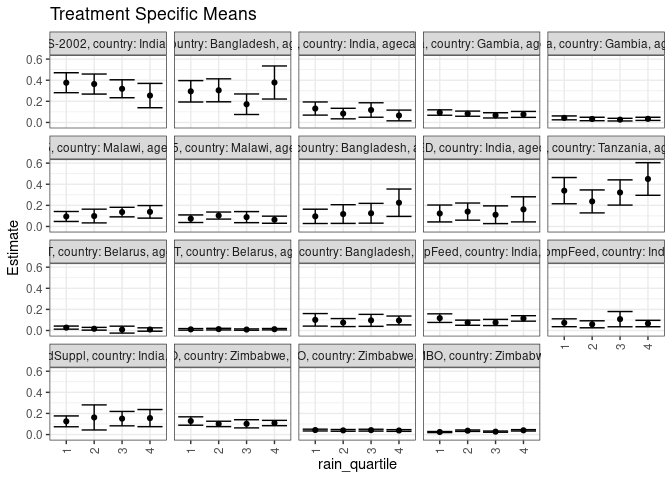

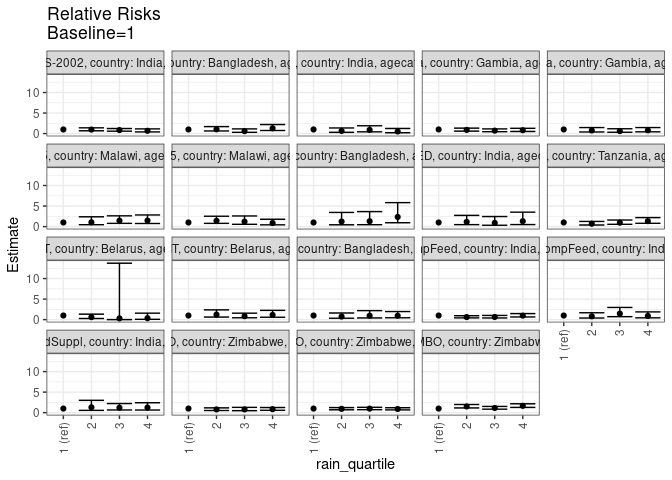

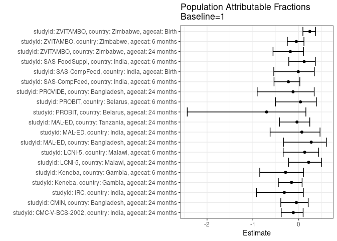

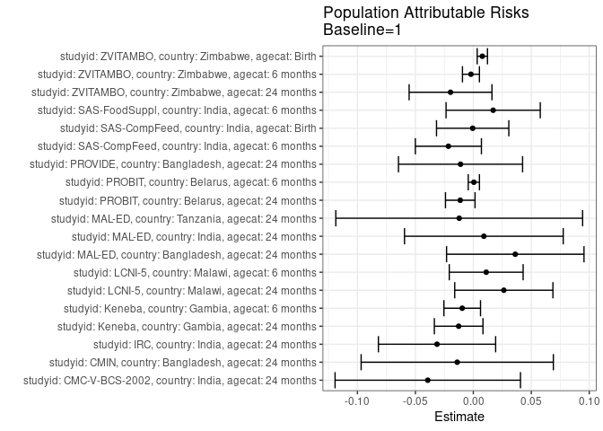

## Results Table

### Parameter: TSM

| studyid | country | agecat | intervention_level | baseline_level | estimate | ci_lower | ci_upper |
| --- | --- | --- | --- | --- | --- | --- | --- |
| CMC-V-BCS-2002 | India | 24 months | 1 | NA | 0.3762376 | 0.2816326 | 0.4708426 |
| CMC-V-BCS-2002 | India | 24 months | 2 | NA | 0.3636364 | 0.2687502 | 0.4585225 |
| CMC-V-BCS-2002 | India | 24 months | 3 | NA | 0.3189655 | 0.2340354 | 0.4038956 |
| CMC-V-BCS-2002 | India | 24 months | 4 | NA | 0.2545455 | 0.1392675 | 0.3698234 |
| CMIN | Bangladesh | 24 months | 1 | NA | 0.2948718 | 0.1934688 | 0.3962747 |
| CMIN | Bangladesh | 24 months | 2 | NA | 0.3043478 | 0.1955541 | 0.4131416 |
| CMIN | Bangladesh | 24 months | 3 | NA | 0.1724138 | 0.0749988 | 0.2698288 |
| CMIN | Bangladesh | 24 months | 4 | NA | 0.3783784 | 0.2217853 | 0.5349715 |
| IRC | India | 24 months | 1 | NA | 0.1315789 | 0.0694512 | 0.1937067 |
| IRC | India | 24 months | 2 | NA | 0.0840336 | 0.0341253 | 0.1339419 |
| IRC | India | 24 months | 3 | NA | 0.1176471 | 0.0490695 | 0.1862246 |
| IRC | India | 24 months | 4 | NA | 0.0659341 | 0.0148833 | 0.1169849 |
| Keneba | Gambia | 6 months | 1 | NA | 0.0431034 | 0.0246201 | 0.0615868 |
| Keneba | Gambia | 6 months | 2 | NA | 0.0326797 | 0.0164104 | 0.0489491 |
| Keneba | Gambia | 6 months | 3 | NA | 0.0264026 | 0.0136345 | 0.0391708 |
| Keneba | Gambia | 6 months | 4 | NA | 0.0339286 | 0.0189302 | 0.0489270 |
| Keneba | Gambia | 24 months | 1 | NA | 0.0938124 | 0.0682739 | 0.1193508 |
| Keneba | Gambia | 24 months | 2 | NA | 0.0829960 | 0.0586613 | 0.1073306 |
| Keneba | Gambia | 24 months | 3 | NA | 0.0670103 | 0.0421236 | 0.0918970 |
| Keneba | Gambia | 24 months | 4 | NA | 0.0760234 | 0.0479261 | 0.1041207 |
| LCNI-5 | Malawi | 6 months | 1 | NA | 0.0735294 | 0.0376919 | 0.1093670 |
| LCNI-5 | Malawi | 6 months | 2 | NA | 0.1034483 | 0.0700087 | 0.1368879 |
| LCNI-5 | Malawi | 6 months | 3 | NA | 0.0884956 | 0.0360984 | 0.1408928 |
| LCNI-5 | Malawi | 6 months | 4 | NA | 0.0640394 | 0.0303408 | 0.0977380 |
| LCNI-5 | Malawi | 24 months | 1 | NA | 0.0945946 | 0.0474049 | 0.1417843 |
| LCNI-5 | Malawi | 24 months | 2 | NA | 0.0987654 | 0.0337371 | 0.1637937 |
| LCNI-5 | Malawi | 24 months | 3 | NA | 0.1363636 | 0.0909771 | 0.1817502 |
| LCNI-5 | Malawi | 24 months | 4 | NA | 0.1384615 | 0.0790387 | 0.1978844 |
| MAL-ED | Bangladesh | 24 months | 1 | NA | 0.0958904 | 0.0281869 | 0.1635940 |
| MAL-ED | Bangladesh | 24 months | 2 | NA | 0.1176471 | 0.0290128 | 0.2062813 |
| MAL-ED | Bangladesh | 24 months | 3 | NA | 0.1250000 | 0.0312194 | 0.2187806 |
| MAL-ED | Bangladesh | 24 months | 4 | NA | 0.2250000 | 0.0952860 | 0.3547140 |
| MAL-ED | India | 24 months | 1 | NA | 0.1230769 | 0.0430347 | 0.2031192 |
| MAL-ED | India | 24 months | 2 | NA | 0.1408451 | 0.0597519 | 0.2219382 |
| MAL-ED | India | 24 months | 3 | NA | 0.1111111 | 0.0271047 | 0.1951175 |
| MAL-ED | India | 24 months | 4 | NA | 0.1621622 | 0.0431310 | 0.2811933 |
| MAL-ED | Tanzania | 24 months | 1 | NA | 0.3392857 | 0.2149887 | 0.4635828 |
| MAL-ED | Tanzania | 24 months | 2 | NA | 0.2372881 | 0.1284810 | 0.3460953 |
| MAL-ED | Tanzania | 24 months | 3 | NA | 0.3220339 | 0.2025267 | 0.4415411 |
| MAL-ED | Tanzania | 24 months | 4 | NA | 0.4500000 | 0.2954664 | 0.6045336 |
| PROBIT | Belarus | 6 months | 1 | NA | 0.0107944 | 0.0030196 | 0.0185691 |
| PROBIT | Belarus | 6 months | 2 | NA | 0.0131537 | 0.0053691 | 0.0209382 |
| PROBIT | Belarus | 6 months | 3 | NA | 0.0090849 | 0.0027251 | 0.0154446 |
| PROBIT | Belarus | 6 months | 4 | NA | 0.0123976 | 0.0058712 | 0.0189240 |
| PROBIT | Belarus | 24 months | 1 | NA | 0.0273973 | 0.0127068 | 0.0420878 |
| PROBIT | Belarus | 24 months | 2 | NA | 0.0165505 | 0.0035330 | 0.0295680 |
| PROBIT | Belarus | 24 months | 3 | NA | 0.0082840 | -0.0246105 | 0.0411786 |
| PROBIT | Belarus | 24 months | 4 | NA | 0.0095037 | -0.0064745 | 0.0254819 |
| PROVIDE | Bangladesh | 24 months | 1 | NA | 0.1010101 | 0.0415992 | 0.1604210 |
| PROVIDE | Bangladesh | 24 months | 2 | NA | 0.0752688 | 0.0373213 | 0.1132163 |
| PROVIDE | Bangladesh | 24 months | 3 | NA | 0.0961538 | 0.0394467 | 0.1528610 |
| PROVIDE | Bangladesh | 24 months | 4 | NA | 0.0952381 | 0.0533524 | 0.1371238 |
| SAS-CompFeed | India | Birth | 1 | NA | 0.0732601 | 0.0360460 | 0.1104741 |
| SAS-CompFeed | India | Birth | 2 | NA | 0.0588235 | 0.0256265 | 0.0920206 |
| SAS-CompFeed | India | Birth | 3 | NA | 0.1076233 | 0.0353879 | 0.1798587 |
| SAS-CompFeed | India | Birth | 4 | NA | 0.0660920 | 0.0357169 | 0.0964670 |
| SAS-CompFeed | India | 6 months | 1 | NA | 0.1173333 | 0.0766185 | 0.1580482 |
| SAS-CompFeed | India | 6 months | 2 | NA | 0.0739130 | 0.0496116 | 0.0982145 |
| SAS-CompFeed | India | 6 months | 3 | NA | 0.0760369 | 0.0467941 | 0.1052796 |
| SAS-CompFeed | India | 6 months | 4 | NA | 0.1144781 | 0.0885942 | 0.1403620 |
| SAS-FoodSuppl | India | 6 months | 1 | NA | 0.1250000 | 0.0736880 | 0.1763120 |
| SAS-FoodSuppl | India | 6 months | 2 | NA | 0.1621622 | 0.0432369 | 0.2810874 |
| SAS-FoodSuppl | India | 6 months | 3 | NA | 0.1509434 | 0.0827028 | 0.2191840 |
| SAS-FoodSuppl | India | 6 months | 4 | NA | 0.1558442 | 0.0747235 | 0.2369648 |
| ZVITAMBO | Zimbabwe | Birth | 1 | NA | 0.0241093 | 0.0191886 | 0.0290300 |
| ZVITAMBO | Zimbabwe | Birth | 2 | NA | 0.0364732 | 0.0299295 | 0.0430169 |
| ZVITAMBO | Zimbabwe | Birth | 3 | NA | 0.0274964 | 0.0220435 | 0.0329492 |
| ZVITAMBO | Zimbabwe | Birth | 4 | NA | 0.0401811 | 0.0337062 | 0.0466560 |
| ZVITAMBO | Zimbabwe | 6 months | 1 | NA | 0.0425532 | 0.0340444 | 0.0510620 |
| ZVITAMBO | Zimbabwe | 6 months | 2 | NA | 0.0395204 | 0.0314732 | 0.0475676 |
| ZVITAMBO | Zimbabwe | 6 months | 3 | NA | 0.0417288 | 0.0329928 | 0.0504648 |
| ZVITAMBO | Zimbabwe | 6 months | 4 | NA | 0.0383586 | 0.0304081 | 0.0463091 |
| ZVITAMBO | Zimbabwe | 24 months | 1 | NA | 0.1282051 | 0.0885354 | 0.1678748 |
| ZVITAMBO | Zimbabwe | 24 months | 2 | NA | 0.1007463 | 0.0752572 | 0.1262353 |
| ZVITAMBO | Zimbabwe | 24 months | 3 | NA | 0.1016949 | 0.0631217 | 0.1402682 |
| ZVITAMBO | Zimbabwe | 24 months | 4 | NA | 0.1092437 | 0.0841711 | 0.1343163 |

### Parameter: E(Y)

| studyid | country | agecat | intervention_level | baseline_level | estimate | ci_lower | ci_upper |
| --- | --- | --- | --- | --- | --- | --- | --- |
| CMC-V-BCS-2002 | India | 24 months | NA | NA | 0.3369272 | 0.2887662 | 0.3850883 |
| CMIN | Bangladesh | 24 months | NA | NA | 0.2809917 | 0.2242434 | 0.3377401 |
| IRC | India | 24 months | NA | NA | 0.1002445 | 0.0711031 | 0.1293859 |
| Keneba | Gambia | 6 months | NA | NA | 0.0335089 | 0.0257898 | 0.0412279 |
| Keneba | Gambia | 24 months | NA | NA | 0.0811594 | 0.0682689 | 0.0940499 |
| LCNI-5 | Malawi | 6 months | NA | NA | 0.0846246 | 0.0657805 | 0.1034686 |
| LCNI-5 | Malawi | 24 months | NA | NA | 0.1208981 | 0.0943206 | 0.1474756 |
| MAL-ED | Bangladesh | 24 months | NA | NA | 0.1320755 | 0.0863920 | 0.1777589 |
| MAL-ED | India | 24 months | NA | NA | 0.1321586 | 0.0880054 | 0.1763117 |
| MAL-ED | Tanzania | 24 months | NA | NA | 0.3271028 | 0.2640978 | 0.3901078 |
| PROBIT | Belarus | 6 months | NA | NA | 0.0112310 | 0.0054733 | 0.0169886 |
| PROBIT | Belarus | 24 months | NA | NA | 0.0161090 | 0.0017796 | 0.0304385 |
| PROVIDE | Bangladesh | 24 months | NA | NA | 0.0899654 | 0.0666186 | 0.1133122 |
| SAS-CompFeed | India | Birth | NA | NA | 0.0726837 | 0.0523147 | 0.0930527 |
| SAS-CompFeed | India | 6 months | NA | NA | 0.0958084 | 0.0774939 | 0.1141229 |
| SAS-FoodSuppl | India | 6 months | NA | NA | 0.1421053 | 0.1069532 | 0.1772573 |
| ZVITAMBO | Zimbabwe | Birth | NA | NA | 0.0318559 | 0.0289336 | 0.0347781 |
| ZVITAMBO | Zimbabwe | 6 months | NA | NA | 0.0404891 | 0.0363397 | 0.0446385 |
| ZVITAMBO | Zimbabwe | 24 months | NA | NA | 0.1085366 | 0.0934775 | 0.1235957 |

### Parameter: RR

| studyid | country | agecat | intervention_level | baseline_level | estimate | ci_lower | ci_upper |
| --- | --- | --- | --- | --- | --- | --- | --- |
| CMC-V-BCS-2002 | India | 24 months | 1 | 1 | 1.0000000 | 1.0000000 | 1.000000 |
| CMC-V-BCS-2002 | India | 24 months | 2 | 1 | 0.9665072 | 0.6727099 | 1.388617 |
| CMC-V-BCS-2002 | India | 24 months | 3 | 1 | 0.8477768 | 0.5877995 | 1.222739 |
| CMC-V-BCS-2002 | India | 24 months | 4 | 1 | 0.6765550 | 0.4030306 | 1.135712 |
| CMIN | Bangladesh | 24 months | 1 | 1 | 1.0000000 | 1.0000000 | 1.000000 |
| CMIN | Bangladesh | 24 months | 2 | 1 | 1.0321361 | 0.6285158 | 1.694953 |
| CMIN | Bangladesh | 24 months | 3 | 1 | 0.5847076 | 0.3017745 | 1.132909 |
| CMIN | Bangladesh | 24 months | 4 | 1 | 1.2831962 | 0.7492150 | 2.197757 |
| IRC | India | 24 months | 1 | 1 | 1.0000000 | 1.0000000 | 1.000000 |
| IRC | India | 24 months | 2 | 1 | 0.6386555 | 0.2990570 | 1.363890 |
| IRC | India | 24 months | 3 | 1 | 0.8941176 | 0.4222870 | 1.893135 |
| IRC | India | 24 months | 4 | 1 | 0.5010989 | 0.2023337 | 1.241019 |
| Keneba | Gambia | 6 months | 1 | 1 | 1.0000000 | 1.0000000 | 1.000000 |
| Keneba | Gambia | 6 months | 2 | 1 | 0.7581699 | 0.3930147 | 1.462596 |
| Keneba | Gambia | 6 months | 3 | 1 | 0.6125413 | 0.3209494 | 1.169053 |
| Keneba | Gambia | 6 months | 4 | 1 | 0.7871429 | 0.4251909 | 1.457213 |
| Keneba | Gambia | 24 months | 1 | 1 | 1.0000000 | 1.0000000 | 1.000000 |
| Keneba | Gambia | 24 months | 2 | 1 | 0.8847015 | 0.5929766 | 1.319945 |
| Keneba | Gambia | 24 months | 3 | 1 | 0.7143014 | 0.4507131 | 1.132043 |
| Keneba | Gambia | 24 months | 4 | 1 | 0.8103770 | 0.5120769 | 1.282446 |
| LCNI-5 | Malawi | 6 months | 1 | 1 | 1.0000000 | 1.0000000 | 1.000000 |
| LCNI-5 | Malawi | 6 months | 2 | 1 | 1.4068966 | 0.7839143 | 2.524967 |
| LCNI-5 | Malawi | 6 months | 3 | 1 | 1.2035398 | 0.5589912 | 2.591290 |
| LCNI-5 | Malawi | 6 months | 4 | 1 | 0.8709360 | 0.4250958 | 1.784373 |
| LCNI-5 | Malawi | 24 months | 1 | 1 | 1.0000000 | 1.0000000 | 1.000000 |
| LCNI-5 | Malawi | 24 months | 2 | 1 | 1.0440917 | 0.4570743 | 2.385012 |
| LCNI-5 | Malawi | 24 months | 3 | 1 | 1.4415584 | 0.7913797 | 2.625909 |
| LCNI-5 | Malawi | 24 months | 4 | 1 | 1.4637363 | 0.7580010 | 2.826545 |
| MAL-ED | Bangladesh | 24 months | 1 | 1 | 1.0000000 | 1.0000000 | 1.000000 |
| MAL-ED | Bangladesh | 24 months | 2 | 1 | 1.2268908 | 0.4369043 | 3.445288 |
| MAL-ED | Bangladesh | 24 months | 3 | 1 | 1.3035714 | 0.4652765 | 3.652234 |
| MAL-ED | Bangladesh | 24 months | 4 | 1 | 2.3464286 | 0.9430599 | 5.838152 |
| MAL-ED | India | 24 months | 1 | 1 | 1.0000000 | 1.0000000 | 1.000000 |
| MAL-ED | India | 24 months | 2 | 1 | 1.1443662 | 0.4801108 | 2.727650 |
| MAL-ED | India | 24 months | 3 | 1 | 0.9027778 | 0.3330176 | 2.447341 |
| MAL-ED | India | 24 months | 4 | 1 | 1.3175676 | 0.4941600 | 3.513001 |
| MAL-ED | Tanzania | 24 months | 1 | 1 | 1.0000000 | 1.0000000 | 1.000000 |
| MAL-ED | Tanzania | 24 months | 2 | 1 | 0.6993756 | 0.3888790 | 1.257785 |
| MAL-ED | Tanzania | 24 months | 3 | 1 | 0.9491525 | 0.5634635 | 1.598845 |
| MAL-ED | Tanzania | 24 months | 4 | 1 | 1.3263158 | 0.8027346 | 2.191401 |
| PROBIT | Belarus | 6 months | 1 | 1 | 1.0000000 | 1.0000000 | 1.000000 |
| PROBIT | Belarus | 6 months | 2 | 1 | 1.2185698 | 0.6247829 | 2.376685 |
| PROBIT | Belarus | 6 months | 3 | 1 | 0.8416313 | 0.4511241 | 1.570174 |
| PROBIT | Belarus | 6 months | 4 | 1 | 1.1485272 | 0.5855812 | 2.252659 |
| PROBIT | Belarus | 24 months | 1 | 1 | 1.0000000 | 1.0000000 | 1.000000 |
| PROBIT | Belarus | 24 months | 2 | 1 | 0.6040941 | 0.2726285 | 1.338560 |
| PROBIT | Belarus | 24 months | 3 | 1 | 0.3023669 | 0.0066552 | 13.737526 |
| PROBIT | Belarus | 24 months | 4 | 1 | 0.3468849 | 0.0762789 | 1.577489 |
| PROVIDE | Bangladesh | 24 months | 1 | 1 | 1.0000000 | 1.0000000 | 1.000000 |
| PROVIDE | Bangladesh | 24 months | 2 | 1 | 0.7451613 | 0.3434109 | 1.616913 |
| PROVIDE | Bangladesh | 24 months | 3 | 1 | 0.9519231 | 0.4138759 | 2.189442 |
| PROVIDE | Bangladesh | 24 months | 4 | 1 | 0.9428571 | 0.4523696 | 1.965162 |
| SAS-CompFeed | India | Birth | 1 | 1 | 1.0000000 | 1.0000000 | 1.000000 |
| SAS-CompFeed | India | Birth | 2 | 1 | 0.8029412 | 0.3851949 | 1.673736 |
| SAS-CompFeed | India | Birth | 3 | 1 | 1.4690583 | 0.7255009 | 2.974679 |
| SAS-CompFeed | India | Birth | 4 | 1 | 0.9021552 | 0.4333698 | 1.878036 |
| SAS-CompFeed | India | 6 months | 1 | 1 | 1.0000000 | 1.0000000 | 1.000000 |
| SAS-CompFeed | India | 6 months | 2 | 1 | 0.6299407 | 0.4173414 | 0.950841 |
| SAS-CompFeed | India | 6 months | 3 | 1 | 0.6480415 | 0.4087774 | 1.027351 |
| SAS-CompFeed | India | 6 months | 4 | 1 | 0.9756657 | 0.6470893 | 1.471086 |
| SAS-FoodSuppl | India | 6 months | 1 | 1 | 1.0000000 | 1.0000000 | 1.000000 |
| SAS-FoodSuppl | India | 6 months | 2 | 1 | 1.2972973 | 0.5598095 | 3.006345 |
| SAS-FoodSuppl | India | 6 months | 3 | 1 | 1.2075472 | 0.6556940 | 2.223858 |
| SAS-FoodSuppl | India | 6 months | 4 | 1 | 1.2467532 | 0.6425121 | 2.419244 |
| ZVITAMBO | Zimbabwe | Birth | 1 | 1 | 1.0000000 | 1.0000000 | 1.000000 |
| ZVITAMBO | Zimbabwe | Birth | 2 | 1 | 1.5128273 | 1.1528490 | 1.985209 |
| ZVITAMBO | Zimbabwe | Birth | 3 | 1 | 1.1404888 | 0.8580265 | 1.515938 |
| ZVITAMBO | Zimbabwe | Birth | 4 | 1 | 1.6666226 | 1.2849922 | 2.161594 |
| ZVITAMBO | Zimbabwe | 6 months | 1 | 1 | 1.0000000 | 1.0000000 | 1.000000 |
| ZVITAMBO | Zimbabwe | 6 months | 2 | 1 | 0.9287300 | 0.6981498 | 1.235465 |
| ZVITAMBO | Zimbabwe | 6 months | 3 | 1 | 0.9806259 | 0.7341325 | 1.309882 |
| ZVITAMBO | Zimbabwe | 6 months | 4 | 1 | 0.9014273 | 0.6758574 | 1.202282 |
| ZVITAMBO | Zimbabwe | 24 months | 1 | 1 | 1.0000000 | 1.0000000 | 1.000000 |
| ZVITAMBO | Zimbabwe | 24 months | 2 | 1 | 0.7858209 | 0.5269140 | 1.171946 |
| ZVITAMBO | Zimbabwe | 24 months | 3 | 1 | 0.7932203 | 0.4861888 | 1.294144 |
| ZVITAMBO | Zimbabwe | 24 months | 4 | 1 | 0.8521008 | 0.5796671 | 1.252574 |

### Parameter: PAR

| studyid | country | agecat | intervention_level | baseline_level | estimate | ci_lower | ci_upper |
| --- | --- | --- | --- | --- | --- | --- | --- |
| CMC-V-BCS-2002 | India | 24 months | 1 | NA | -0.0393104 | -0.1192885 | 0.0406677 |
| CMIN | Bangladesh | 24 months | 1 | NA | -0.0138801 | -0.0967927 | 0.0690326 |
| IRC | India | 24 months | 1 | NA | -0.0313344 | -0.0819049 | 0.0192360 |
| Keneba | Gambia | 6 months | 1 | NA | -0.0095946 | -0.0253887 | 0.0061995 |
| Keneba | Gambia | 24 months | 1 | NA | -0.0126530 | -0.0336178 | 0.0083119 |
| LCNI-5 | Malawi | 6 months | 1 | NA | 0.0110951 | -0.0207618 | 0.0429521 |
| LCNI-5 | Malawi | 24 months | 1 | NA | 0.0263035 | -0.0160615 | 0.0686685 |
| MAL-ED | Bangladesh | 24 months | 1 | NA | 0.0361851 | -0.0230940 | 0.0954641 |
| MAL-ED | India | 24 months | 1 | NA | 0.0090817 | -0.0593814 | 0.0775447 |
| MAL-ED | Tanzania | 24 months | 1 | NA | -0.0121829 | -0.1186420 | 0.0942761 |
| PROBIT | Belarus | 6 months | 1 | NA | 0.0004366 | -0.0043963 | 0.0052696 |
| PROBIT | Belarus | 24 months | 1 | NA | -0.0112882 | -0.0240369 | 0.0014604 |
| PROVIDE | Bangladesh | 24 months | 1 | NA | -0.0110447 | -0.0645761 | 0.0424867 |
| SAS-CompFeed | India | Birth | 1 | NA | -0.0005764 | -0.0317676 | 0.0306149 |
| SAS-CompFeed | India | 6 months | 1 | NA | -0.0215250 | -0.0500183 | 0.0069684 |
| SAS-FoodSuppl | India | 6 months | 1 | NA | 0.0171053 | -0.0235321 | 0.0577426 |
| ZVITAMBO | Zimbabwe | Birth | 1 | NA | 0.0077466 | 0.0033054 | 0.0121877 |
| ZVITAMBO | Zimbabwe | 6 months | 1 | NA | -0.0020641 | -0.0093788 | 0.0052506 |
| ZVITAMBO | Zimbabwe | 24 months | 1 | NA | -0.0196685 | -0.0553972 | 0.0160602 |

### Parameter: PAF

| studyid | country | agecat | intervention_level | baseline_level | estimate | ci_lower | ci_upper |
| --- | --- | --- | --- | --- | --- | --- | --- |
| CMC-V-BCS-2002 | India | 24 months | 1 | NA | -0.1166733 | -0.3812625 | 0.0972323 |
| CMIN | Bangladesh | 24 months | 1 | NA | -0.0493967 | -0.3900901 | 0.2077971 |
| IRC | India | 24 months | 1 | NA | -0.3125802 | -0.9191714 | 0.1022861 |
| Keneba | Gambia | 6 months | 1 | NA | -0.2863300 | -0.8495341 | 0.1053720 |
| Keneba | Gambia | 24 months | 1 | NA | -0.1559025 | -0.4441769 | 0.0748290 |
| LCNI-5 | Malawi | 6 months | 1 | NA | 0.1311102 | -0.3385954 | 0.4359987 |
| LCNI-5 | Malawi | 24 months | 1 | NA | 0.2175676 | -0.2204569 | 0.4983842 |
| MAL-ED | Bangladesh | 24 months | 1 | NA | 0.2739726 | -0.3326887 | 0.6044719 |
| MAL-ED | India | 24 months | 1 | NA | 0.0687179 | -0.6236519 | 0.4658422 |
| MAL-ED | Tanzania | 24 months | 1 | NA | -0.0372449 | -0.4195540 | 0.2421021 |
| PROBIT | Belarus | 6 months | 1 | NA | 0.0388756 | -0.5068513 | 0.3869600 |
| PROBIT | Belarus | 24 months | 1 | NA | -0.7007376 | -2.4317174 | 0.1571251 |
| PROVIDE | Bangladesh | 24 months | 1 | NA | -0.1227661 | -0.9063009 | 0.3387173 |
| SAS-CompFeed | India | Birth | 1 | NA | -0.0079298 | -0.5429098 | 0.3415542 |
| SAS-CompFeed | India | 6 months | 1 | NA | -0.2246667 | -0.5379087 | 0.0247740 |
| SAS-FoodSuppl | India | 6 months | 1 | NA | 0.1203704 | -0.2160319 | 0.3637105 |
| ZVITAMBO | Zimbabwe | Birth | 1 | NA | 0.2431754 | 0.0921440 | 0.3690811 |
| ZVITAMBO | Zimbabwe | 6 months | 1 | NA | -0.0509790 | -0.2480123 | 0.1149472 |
| ZVITAMBO | Zimbabwe | 24 months | 1 | NA | -0.1812158 | -0.5599416 | 0.1055622 |